# GSEA_Cutsom_Genes

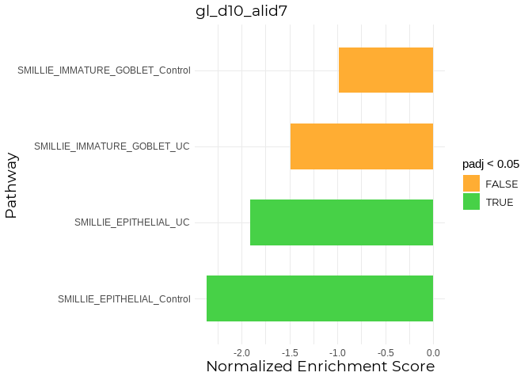

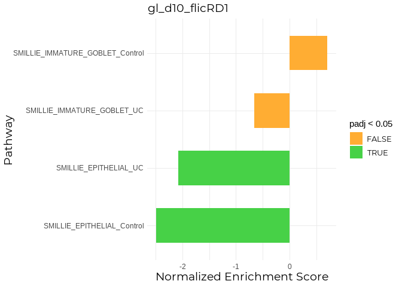

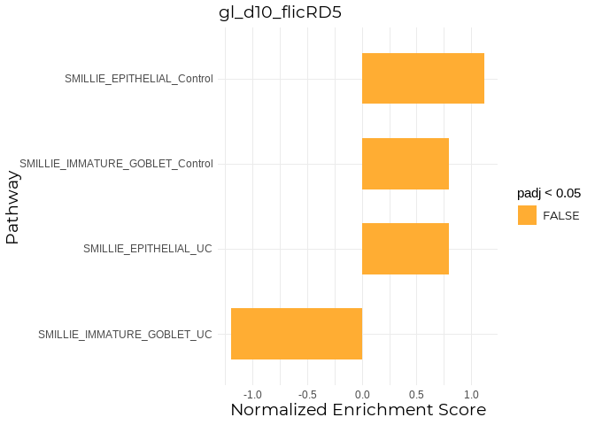

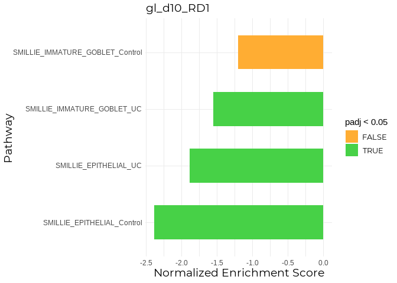

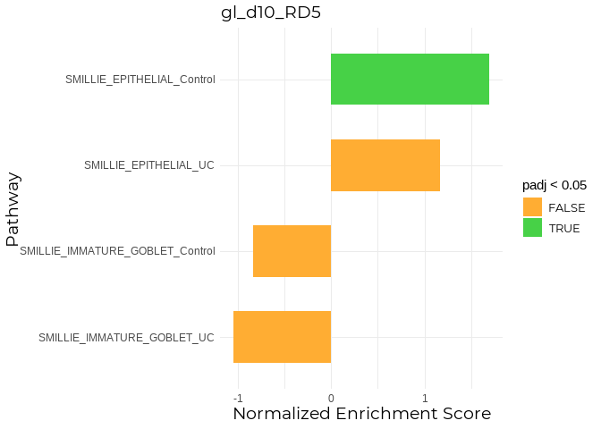

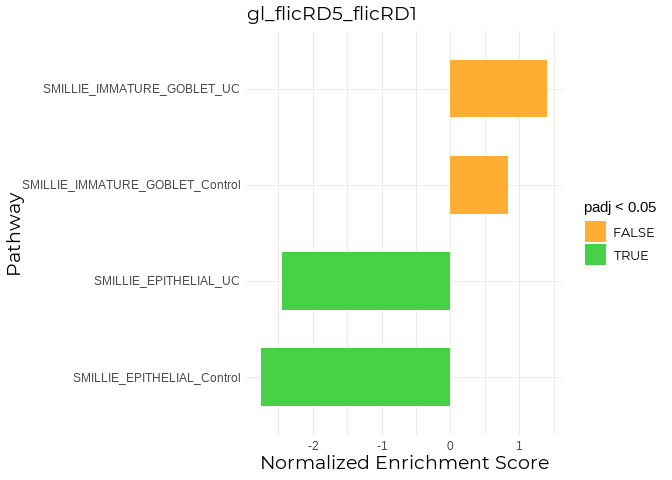

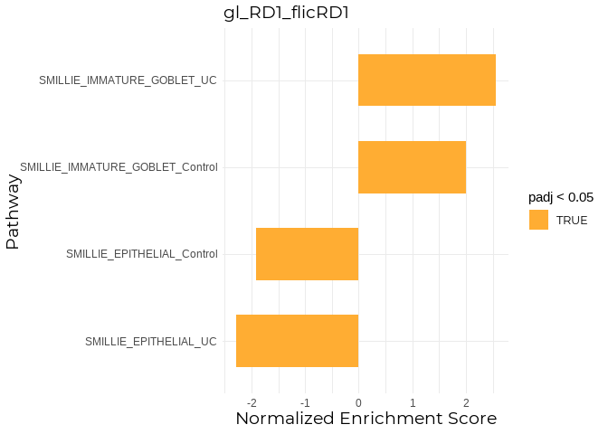

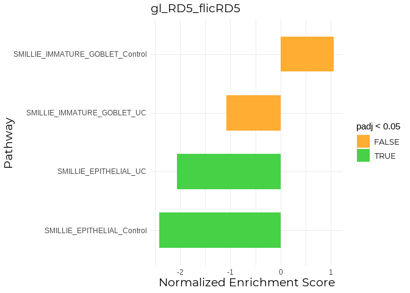

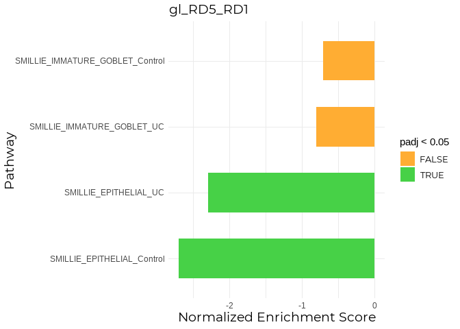

```r
smillie_markers <- as.data.frame(rbind(epithelial_uc, epithelial_control, goblet_uc, goblet_control))
smillie_markers <- split(x = smillie_markers$gene, f = smillie_markers$term)

fgsea_smillie <- list()

for (i in 1:length(all_gl)){
fgsea_smillie[[i]] <- fgsea(smillie_markers, all_gl[[i]])
}

names(fgsea_smillie) <- names(all_gl)
#write.xlsx(fgsea_smillie, file = here::here("data", "Processed", "ibd_fgsea_smillie_results.xlsx"), colnames = TRUE)

smillie_NES_plots <- list()

for (i in seq_along(fgsea_smillie)){
  x <- ggplot(fgsea_smillie[[i]], aes(x = reorder(pathway, NES), y = NES)) +
    geom_col(aes(fill = padj < 0.05, width = 0.6)) +
    scale_fill_manual(values = c("#ffad33", "#47d147")) +
    coord_flip() +
    labs(x = "Pathway", y = "Normalized Enrichment Score") +
    ggtitle(names(fgsea_smillie[i])) +
    my_theme
  smillie_NES_plots[[i]] <- x
}

names(smillie_NES_plots) <- names(all_gl)

smillie_NES_plots
```

I’m actually going totry to run this GSEA via the software. Using `d10_alid7` as an example, I’ll prepare the `.rnk` file required by the software, consisting of the gene identifier in the first column and the ranking metric in the second(the log2FC). I’ll manually add the `.rnk` extension to saved excel file.

The geneset file requires each row (`.gmt`) or each column (`.gmx`) to be one geneset, with the name of the geneset in the first column/header, and the gene identifiers in subsequent columns after that. I’ll manually add the extension to saved excel file.

The [guide to making the files](https://software.broadinstitute.org/cancer/software/gsea/wiki/index.php/Data_formats#RNK:_Ranked_list_file_format_.28.2A.rnk.29) details the formatting required to run the [preranked GSEA](https://www.gsea-msigdb.org/gsea/doc/GSEAUserGuideFrame.html?_GSEAPreranked_Page)

```r
ali_d7_rnk <- all_metrics[[1]]

head(ali_d7_rnk)
```

```
##    GeneName   baseMean log2FoldChange     lfcSE          stat     pvalue
## 1    WASH7P   11.20226   0.0001113504 0.2257570  0.0004932314 0.99960646
## 2 LINC01128  108.47368   0.0786379542 0.2804633  0.2803859343 0.77918143
## 3     NOC2L 2557.14285   0.0445676651 0.1699291  0.2622720440 0.79311171
## 4    KLHL17   95.31694  -0.0081250770 0.2847301 -0.0285360664 0.97723460
## 5   PLEKHN1  102.91997  -0.4653728423 0.2820543 -1.6499408170 0.09895504
## 6      HES4  101.73257   0.0173193398 0.2824137  0.0613261314 0.95109948
##        padj status Significant entrezgene_id
## 1 0.9998297     OK          No        653635
## 2 0.9989866     OK          No        643837
## 3 0.9989866     OK          No         26155
## 4 0.9989866     OK          No        339451
## 5 0.6496130     OK          No         84069
## 6 0.9989866     OK          No         57801
```

```r
ali_d7_rnk <- ali_d7_rnk %>%
  select(GeneName, log2FoldChange)

#write.xlsx(ali_d7_rnk, file = here::here("data", "Processed", "d10_alid7_rnk.xlsx"), colnames = TRUE)

smillie_gmt <- smillie %>%
  unite("term", cell_type:Condition)

smillie_gmt
```

```
## # A tibble: 292 x 3
##    term            gene_symbol   gene
##    <chr>           <chr>        <dbl>
##  1 E_epithelial_UC TNFRSF1A      7132
##  2 E_epithelial_UC IFNGR2        3460
##  3 E_epithelial_UC TNFSF10       8743
##  4 E_epithelial_UC SMPD1         6609
##  5 E_epithelial_UC SPATA2L     124044
##  6 E_epithelial_UC PARP4          143
##  7 E_epithelial_UC CHMP1A        5119
##  8 E_epithelial_UC TICAM1      148022
##  9 E_epithelial_UC EZR           7430
## 10 E_epithelial_UC CGN          57530
## # ... with 282 more rows
```

```r
smillie_gmt <- smillie_gmt %>%
  select(term, gene_symbol)

smillie_gmt <- split(x = smillie_gmt$gene_symbol, f = smillie_gmt$term)

#write.xlsx(smillie_gmt, file = here::here("data", "Processed", "smillie_gmt.xlsx"), colnames = TRUE)
```

Okay, so the enrichment results table outputs a similar NES as is in our `fgsea_smillie` object, with a minor decimal number difference (i.e. 0.71 instead of 0.72.). Let’s compare:

```r
as_tibble(fgsea_smillie[[1]])
```

```
## # A tibble: 4 x 8
##   pathway                 pval      padj log2err     ES    NES  size leadingEdge
##   <chr>                  <dbl>     <dbl>   <dbl>  <dbl>  <dbl> <int> <list>
## 1 SMILLIE_EPITHELI~   1   e-10  4   e-10 NA      -0.697 -2.36     93 <chr [51]>
## 2 SMILLIE_EPITHELI~   4.68e- 6  9.35e- 6  0.611  -0.544 -1.91    125 <chr [56]>
## 3 SMILLIE_IMMATURE~   4.60e- 1  4.60e- 1  0.0675 -0.356 -0.988    32 <chr [11]>
## 4 SMILLIE_IMMATURE~   5.55e- 2  7.40e- 2  0.231  -0.542 -1.49     30 <chr [17]>
```

```r
enrich_results_alid7_smillie <- read.delim(here::here("data", "Processed", "gsea_report_alid7_smillie.tsv"), sep = "\t", header = TRUE)

as_tibble(enrich_results_alid7_smillie)
```

```
## # A tibble: 4 x 12
##   NAME     GS.br..follow.lin~ GS.DETAILS  SIZE     ES    NES NOM.p.val FDR.q.val
##   <chr>    <chr>              <chr>      <int>  <dbl>  <dbl>     <dbl>     <dbl>
## 1 E_EPITH~ E_EPITHELIAL_CONT~ Details .~    93 -0.697 -2.37     0         0
## 2 E_EPITH~ E_EPITHELIAL_UC    Details .~   125 -0.544 -1.91     0         0
## 3 IMMATUR~ IMMATURE_GOBLET_UC Details .~    30 -0.542 -1.53     0.0337    0.0238
## 4 IMMATUR~ IMMATURE_GOBLET_C~ Details .~    32 -0.356 -0.987    0.498     0.483
## # ... with 4 more variables: FWER.p.val <dbl>, RANK.AT.MAX <int>,
## #   LEADING.EDGE <chr>, X <lgl>
```

I’ll make all `.rnk` files for all the conditions that we have.

```r
all_rnk_files <- map(all_metrics, function (x) x %>%
  select(GeneName, log2FoldChange))

#write.xlsx(all_rnk_files, file = here::here("data", "Processed", "all_rnk_files.xlsx"), colnames = FALSE)
```

I’m going to do the smillie gene markers GSEA with the software itself, stored in Projects/ibd_steiner/GSEA_software_files.

## 4.0 GSEA Software files

This is how the GSEA files look like:

1. Our ranked log2FC `.rnk` files:

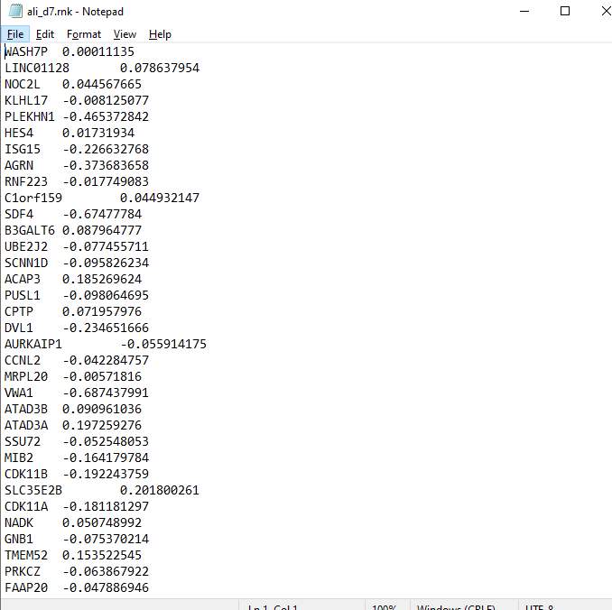

```r
knitr::include_graphics(here::here("images", "rnk_file.png"), error = FALSE)
```

2. Our genesets `.gmx` files:

[figure not shown]

```r
knitr::include_graphics(here::here("images", "gmx_file.png"), error = FALSE)
```

3. GSEAPreranked parameters to choose in the GSEA Software:

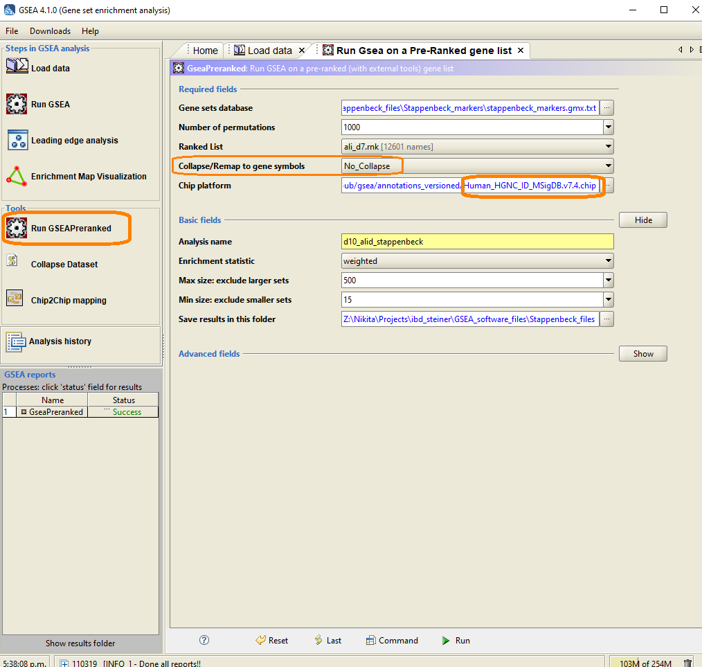

```r
knitr::include_graphics(here::here("images", "GSEA_pre_ranked_parameters.png"), error = FALSE)
```